# Risk Factor Analysis

## Outcome Variable

**Outcome Variable:** haz

## Predictor Variables

**Intervention Variable:** mhtcm

**Adjustment Set:**

unadjusted

## Stratifying Variables

The analysis was stratified on these variable(s):

- agecat
- studyid
- country

## Data Summary

| agecat | studyid | country | mhtcm | n_cell | n |
| --- | --- | --- | --- | --- | --- |
| Birth | ki0047075b-MAL-ED | BANGLADESH | >=155 cm | 25 | 246 |
| Birth | ki0047075b-MAL-ED | BANGLADESH | <151 cm | 156 | 246 |
| Birth | ki0047075b-MAL-ED | BANGLADESH | [151-155) cm | 65 | 246 |
| Birth | ki0047075b-MAL-ED | BRAZIL | >=155 cm | 107 | 184 |
| Birth | ki0047075b-MAL-ED | BRAZIL | <151 cm | 49 | 184 |
| Birth | ki0047075b-MAL-ED | BRAZIL | [151-155) cm | 28 | 184 |
| Birth | ki0047075b-MAL-ED | INDIA | >=155 cm | 46 | 198 |
| Birth | ki0047075b-MAL-ED | INDIA | <151 cm | 95 | 198 |
| Birth | ki0047075b-MAL-ED | INDIA | [151-155) cm | 57 | 198 |
| Birth | ki0047075b-MAL-ED | NEPAL | >=155 cm | 27 | 172 |
| Birth | ki0047075b-MAL-ED | NEPAL | <151 cm | 96 | 172 |
| Birth | ki0047075b-MAL-ED | NEPAL | [151-155) cm | 49 | 172 |
| Birth | ki0047075b-MAL-ED | PERU | >=155 cm | 58 | 276 |
| Birth | ki0047075b-MAL-ED | PERU | <151 cm | 161 | 276 |
| Birth | ki0047075b-MAL-ED | PERU | [151-155) cm | 57 | 276 |
| Birth | ki0047075b-MAL-ED | SOUTH AFRICA | >=155 cm | 173 | 228 |
| Birth | ki0047075b-MAL-ED | SOUTH AFRICA | <151 cm | 29 | 228 |
| Birth | ki0047075b-MAL-ED | SOUTH AFRICA | [151-155) cm | 26 | 228 |
| Birth | ki0047075b-MAL-ED | TANZANIA, UNITED REPUBLIC OF | >=155 cm | 76 | 121 |
| Birth | ki0047075b-MAL-ED | TANZANIA, UNITED REPUBLIC OF | <151 cm | 21 | 121 |
| Birth | ki0047075b-MAL-ED | TANZANIA, UNITED REPUBLIC OF | [151-155) cm | 24 | 121 |
| Birth | ki1000304b-SAS-CompFeed | INDIA | >=155 cm | 59 | 130 |
| Birth | ki1000304b-SAS-CompFeed | INDIA | <151 cm | 33 | 130 |
| Birth | ki1000304b-SAS-CompFeed | INDIA | [151-155) cm | 38 | 130 |
| Birth | ki1017093-NIH-Birth | BANGLADESH | >=155 cm | 7 | 28 |
| Birth | ki1017093-NIH-Birth | BANGLADESH | <151 cm | 15 | 28 |
| Birth | ki1017093-NIH-Birth | BANGLADESH | [151-155) cm | 6 | 28 |
| Birth | ki1017093c-NIH-Crypto | BANGLADESH | >=155 cm | 4 | 27 |
| Birth | ki1017093c-NIH-Crypto | BANGLADESH | <151 cm | 17 | 27 |
| Birth | ki1017093c-NIH-Crypto | BANGLADESH | [151-155) cm | 6 | 27 |

[output cut: 144 more lines]

The following strata were considered:

- agecat: 24 months, studyid: ki0047075b-MAL-ED, country: BANGLADESH
- agecat: 24 months, studyid: ki0047075b-MAL-ED, country: BRAZIL
- agecat: 24 months, studyid: ki0047075b-MAL-ED, country: INDIA
- agecat: 24 months, studyid: ki0047075b-MAL-ED, country: NEPAL
- agecat: 24 months, studyid: ki0047075b-MAL-ED, country: PERU
- agecat: 24 months, studyid: ki0047075b-MAL-ED, country: SOUTH AFRICA
- agecat: 24 months, studyid: ki0047075b-MAL-ED, country: TANZANIA, UNITED REPUBLIC OF
- agecat: 24 months, studyid: ki1017093-NIH-Birth, country: BANGLADESH
- agecat: 24 months, studyid: ki1017093b-PROVIDE, country: BANGLADESH
- agecat: 24 months, studyid: ki1017093c-NIH-Crypto, country: BANGLADESH
- agecat: 24 months, studyid: ki1066203-TanzaniaChild2, country: TANZANIA, UNITED REPUBLIC OF
- agecat: 24 months, studyid: ki1101329-Keneba, country: GAMBIA
- agecat: 24 months, studyid: ki1119695-PROBIT, country: BELARUS
- agecat: 24 months, studyid: ki1126311-ZVITAMBO, country: ZIMBABWE
- agecat: 24 months, studyid: ki1135781-COHORTS, country: GUATEMALA
- agecat: 24 months, studyid: ki1135781-COHORTS, country: INDIA
- agecat: 24 months, studyid: ki1135781-COHORTS, country: PHILIPPINES
- agecat: 24 months, studyid: ki1148112-LCNI-5, country: MALAWI
- agecat: 24 months, studyid: kiGH5241-JiVitA-3, country: BANGLADESH
- agecat: 6 months, studyid: ki0047075b-MAL-ED, country: BANGLADESH
- agecat: 6 months, studyid: ki0047075b-MAL-ED, country: BRAZIL
- agecat: 6 months, studyid: ki0047075b-MAL-ED, country: INDIA
- agecat: 6 months, studyid: ki0047075b-MAL-ED, country: NEPAL
- agecat: 6 months, studyid: ki0047075b-MAL-ED, country: PERU
- agecat: 6 months, studyid: ki0047075b-MAL-ED, country: SOUTH AFRICA
- agecat: 6 months, studyid: ki0047075b-MAL-ED, country: TANZANIA, UNITED REPUBLIC OF
- agecat: 6 months, studyid: ki1000304b-SAS-CompFeed, country: INDIA
- agecat: 6 months, studyid: ki1000304b-SAS-FoodSuppl, country: INDIA
- agecat: 6 months, studyid: ki1017093-NIH-Birth, country: BANGLADESH
- agecat: 6 months, studyid: ki1017093b-PROVIDE, country: BANGLADESH
- agecat: 6 months, studyid: ki1017093c-NIH-Crypto, country: BANGLADESH
- agecat: 6 months, studyid: ki1066203-TanzaniaChild2, country: TANZANIA, UNITED REPUBLIC OF
- agecat: 6 months, studyid: ki1101329-Keneba, country: GAMBIA
- agecat: 6 months, studyid: ki1112895-Guatemala BSC, country: GUATEMALA
- agecat: 6 months, studyid: ki1119695-PROBIT, country: BELARUS
- agecat: 6 months, studyid: ki1126311-ZVITAMBO, country: ZIMBABWE
- agecat: 6 months, studyid: ki1135781-COHORTS, country: GUATEMALA
- agecat: 6 months, studyid: ki1135781-COHORTS, country: INDIA
- agecat: 6 months, studyid: ki1135781-COHORTS, country: PHILIPPINES
- agecat: 6 months, studyid: ki1148112-LCNI-5, country: MALAWI
- agecat: 6 months, studyid: kiGH5241-JiVitA-3, country: BANGLADESH
- agecat: Birth, studyid: ki0047075b-MAL-ED, country: BANGLADESH
- agecat: Birth, studyid: ki0047075b-MAL-ED, country: BRAZIL
- agecat: Birth, studyid: ki0047075b-MAL-ED, country: INDIA
- agecat: Birth, studyid: ki0047075b-MAL-ED, country: NEPAL
- agecat: Birth, studyid: ki0047075b-MAL-ED, country: PERU
- agecat: Birth, studyid: ki0047075b-MAL-ED, country: SOUTH AFRICA
- agecat: Birth, studyid: ki0047075b-MAL-ED, country: TANZANIA, UNITED REPUBLIC OF
- agecat: Birth, studyid: ki1000304b-SAS-CompFeed, country: INDIA
- agecat: Birth, studyid: ki1017093-NIH-Birth, country: BANGLADESH
- agecat: Birth, studyid: ki1017093c-NIH-Crypto, country: BANGLADESH
- agecat: Birth, studyid: ki1101329-Keneba, country: GAMBIA
- agecat: Birth, studyid: ki1119695-PROBIT, country: BELARUS
- agecat: Birth, studyid: ki1126311-ZVITAMBO, country: ZIMBABWE
- agecat: Birth, studyid: ki1135781-COHORTS, country: GUATEMALA
- agecat: Birth, studyid: ki1135781-COHORTS, country: INDIA
- agecat: Birth, studyid: ki1135781-COHORTS, country: PHILIPPINES
- agecat: Birth, studyid: kiGH5241-JiVitA-3, country: BANGLADESH

### Dropped Strata

Some strata were dropped due to rare outcomes:

- agecat: Birth, studyid: ki1017093c-NIH-Crypto, country: BANGLADESH
- agecat: 24 months, studyid: ki1066203-TanzaniaChild2, country: TANZANIA, UNITED REPUBLIC OF

## Methods Detail

We’re interested in the causal parameters $E[Y_a]$ for all values of $a \in \mathcal{A}$. These parameters represent the mean outcome if, possibly contrary to fact, we intervened to set all units to have $A=a$. Under the randomization and positivity assumptions, these are identified by the statistical parameters $\psi_a=E_W[E_{Y|A,W}(Y|A=a,W)]$. In addition, we’re interested in the mean of $Y$, $E[Y]$ under no intervention (the observed mean). We will estimate these parameters by using SuperLearner to fit the relevant likelihood factors – $E_{Y|A,W}(Y|A=a,W)$ and $p(A=a|W)$, and then updating our likelihood fit using a joint TMLE.

For unadjusted analyses ($W=\{\}$), initial likelihoods were estimated using Lrnr_glm to estimate the simple $E(Y|A)$ and Lrnr_mean to estimate $p(A)$. For adjusted analyses, a small library containing Lrnr_glmnet, Lrnr_xgboost, and Lrnr_mean was used.

Having estimated these parameters, we will then use the delta method to estimate relative risks and attributable risks relative to a prespecified baseline level of $A$.

# Results Detail

## Results Plots

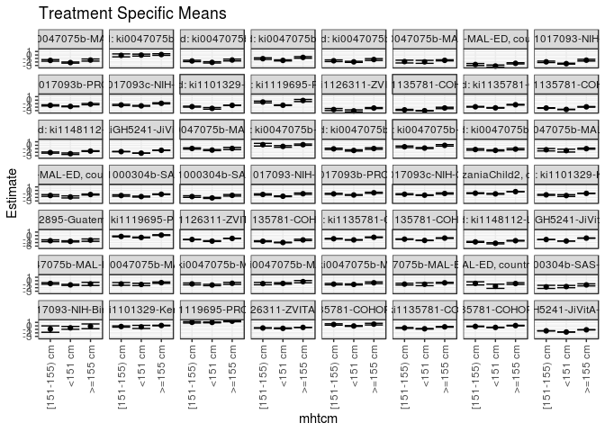

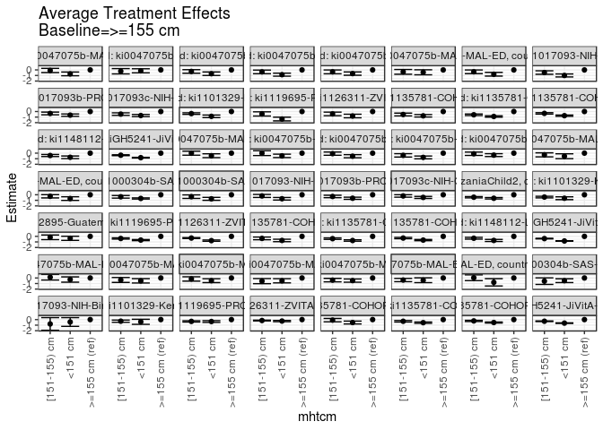

[figure not shown]

## Results Table

### Parameter: TSM

| agecat | studyid | country | intervention_level | baseline_level | estimate | ci_lower | ci_upper |
| --- | --- | --- | --- | --- | --- | --- | --- |
| Birth | ki0047075b-MAL-ED | BANGLADESH | >=155 cm | NA | -0.9036000 | -1.3554697 | -0.4517303 |
| Birth | ki0047075b-MAL-ED | BANGLADESH | <151 cm | NA | -1.1830769 | -1.3406047 | -1.0255491 |
| Birth | ki0047075b-MAL-ED | BANGLADESH | [151-155) cm | NA | -0.7700000 | -0.9862090 | -0.5537910 |
| Birth | ki0047075b-MAL-ED | BRAZIL | >=155 cm | NA | -0.5480374 | -0.7412211 | -0.3548536 |
| Birth | ki0047075b-MAL-ED | BRAZIL | <151 cm | NA | -1.0630612 | -1.4015102 | -0.7246123 |
| Birth | ki0047075b-MAL-ED | BRAZIL | [151-155) cm | NA | -0.9064286 | -1.3061652 | -0.5066919 |
| Birth | ki0047075b-MAL-ED | INDIA | >=155 cm | NA | -0.7356522 | -1.0168746 | -0.4544298 |
| Birth | ki0047075b-MAL-ED | INDIA | <151 cm | NA | -1.2229474 | -1.4230595 | -1.0228352 |
| Birth | ki0047075b-MAL-ED | INDIA | [151-155) cm | NA | -0.9114035 | -1.1801353 | -0.6426717 |
| Birth | ki0047075b-MAL-ED | NEPAL | >=155 cm | NA | -0.2622222 | -0.5780780 | 0.0536335 |
| Birth | ki0047075b-MAL-ED | NEPAL | <151 cm | NA | -0.7680208 | -0.9679771 | -0.5680645 |
| Birth | ki0047075b-MAL-ED | NEPAL | [151-155) cm | NA | -0.8265306 | -1.1603413 | -0.4927200 |
| Birth | ki0047075b-MAL-ED | PERU | >=155 cm | NA | -0.5829310 | -0.8269928 | -0.3388693 |
| Birth | ki0047075b-MAL-ED | PERU | <151 cm | NA | -1.0559006 | -1.2070462 | -0.9047551 |
| Birth | ki0047075b-MAL-ED | PERU | [151-155) cm | NA | -0.9692982 | -1.1674188 | -0.7711777 |
| Birth | ki0047075b-MAL-ED | SOUTH AFRICA | >=155 cm | NA | -0.5979769 | -0.7471724 | -0.4487813 |
| Birth | ki0047075b-MAL-ED | SOUTH AFRICA | <151 cm | NA | -1.0058621 | -1.4127205 | -0.5990037 |
| Birth | ki0047075b-MAL-ED | SOUTH AFRICA | [151-155) cm | NA | -0.9692308 | -1.2242354 | -0.7142262 |
| Birth | ki0047075b-MAL-ED | TANZANIA, UNITED REPUBLIC OF | >=155 cm | NA | -0.7997368 | -1.0504388 | -0.5490348 |
| Birth | ki0047075b-MAL-ED | TANZANIA, UNITED REPUBLIC OF | <151 cm | NA | -1.5800000 | -2.1865062 | -0.9734938 |
| Birth | ki0047075b-MAL-ED | TANZANIA, UNITED REPUBLIC OF | [151-155) cm | NA | -0.7575000 | -1.2033106 | -0.3116894 |
| Birth | ki1000304b-SAS-CompFeed | INDIA | >=155 cm | NA | -1.1901695 | -1.4844022 | -0.8959368 |
| Birth | ki1000304b-SAS-CompFeed | INDIA | <151 cm | NA | -1.6760606 | -2.0046506 | -1.3474706 |
| Birth | ki1000304b-SAS-CompFeed | INDIA | [151-155) cm | NA | -1.7610526 | -2.2018695 | -1.3202358 |
| Birth | ki1017093-NIH-Birth | BANGLADESH | >=155 cm | NA | -0.1300000 | -0.8017283 | 0.5417283 |
| Birth | ki1017093-NIH-Birth | BANGLADESH | <151 cm | NA | -0.5613333 | -0.9683502 | -0.1543165 |
| Birth | ki1017093-NIH-Birth | BANGLADESH | [151-155) cm | NA | -0.9150000 | -1.8302637 | 0.0002637 |
| Birth | ki1101329-Keneba | GAMBIA | >=155 cm | NA | 0.1035919 | 0.0326448 | 0.1745390 |
| Birth | ki1101329-Keneba | GAMBIA | <151 cm | NA | -0.2927451 | -0.7385385 | 0.1530483 |
| Birth | ki1101329-Keneba | GAMBIA | [151-155) cm | NA | -0.1830208 | -0.3681912 | 0.0021496 |

[output cut: 138 more lines]

### Parameter: E(Y)

| agecat | studyid | country | intervention_level | baseline_level | estimate | ci_lower | ci_upper |
| --- | --- | --- | --- | --- | --- | --- | --- |
| Birth | ki0047075b-MAL-ED | BANGLADESH | NA | NA | -1.0455285 | -1.1715695 | -0.9194875 |
| Birth | ki0047075b-MAL-ED | BRAZIL | NA | NA | -0.7397283 | -0.8996215 | -0.5798350 |
| Birth | ki0047075b-MAL-ED | INDIA | NA | NA | -1.0200505 | -1.1624932 | -0.8776078 |
| Birth | ki0047075b-MAL-ED | NEPAL | NA | NA | -0.7052907 | -0.8627483 | -0.5478331 |
| Birth | ki0047075b-MAL-ED | PERU | NA | NA | -0.9386232 | -1.0507144 | -0.8265319 |
| Birth | ki0047075b-MAL-ED | SOUTH AFRICA | NA | NA | -0.6921930 | -0.8218578 | -0.5625282 |
| Birth | ki0047075b-MAL-ED | TANZANIA, UNITED REPUBLIC OF | NA | NA | -0.9267769 | -1.1425813 | -0.7109724 |
| Birth | ki1000304b-SAS-CompFeed | INDIA | NA | NA | -1.4803846 | -1.6742160 | -1.2865532 |
| Birth | ki1017093-NIH-Birth | BANGLADESH | NA | NA | -0.5292857 | -0.8821252 | -0.1764462 |
| Birth | ki1101329-Keneba | GAMBIA | NA | NA | 0.0509377 | -0.0152181 | 0.1170935 |
| Birth | ki1119695-PROBIT | BELARUS | NA | NA | 1.3266356 | 1.1675034 | 1.4857678 |
| Birth | ki1126311-ZVITAMBO | ZIMBABWE | NA | NA | -0.4773539 | -0.5018158 | -0.4528920 |
| Birth | ki1135781-COHORTS | GUATEMALA | NA | NA | 0.1335238 | 0.0490187 | 0.2180289 |
| Birth | ki1135781-COHORTS | INDIA | NA | NA | -0.5973224 | -0.6502394 | -0.5444055 |
| Birth | ki1135781-COHORTS | PHILIPPINES | NA | NA | -0.2490492 | -0.2880580 | -0.2100404 |
| Birth | kiGH5241-JiVitA-3 | BANGLADESH | NA | NA | -1.5749898 | -1.5947766 | -1.5552029 |
| 6 months | ki0047075b-MAL-ED | BANGLADESH | NA | NA | -1.2056777 | -1.3231497 | -1.0882058 |
| 6 months | ki0047075b-MAL-ED | BRAZIL | NA | NA | 0.0510207 | -0.0930194 | 0.1950608 |
| 6 months | ki0047075b-MAL-ED | INDIA | NA | NA | -1.2148369 | -1.3332371 | -1.0964367 |
| 6 months | ki0047075b-MAL-ED | NEPAL | NA | NA | -0.5610593 | -0.6737915 | -0.4483272 |
| 6 months | ki0047075b-MAL-ED | PERU | NA | NA | -1.3272488 | -1.4359649 | -1.2185326 |
| 6 months | ki0047075b-MAL-ED | SOUTH AFRICA | NA | NA | -1.0728012 | -1.2026830 | -0.9429194 |
| 6 months | ki0047075b-MAL-ED | TANZANIA, UNITED REPUBLIC OF | NA | NA | -1.3601215 | -1.4821830 | -1.2380600 |
| 6 months | ki1000304b-SAS-CompFeed | INDIA | NA | NA | -1.4068893 | -1.4981242 | -1.3156543 |
| 6 months | ki1000304b-SAS-FoodSuppl | INDIA | NA | NA | -1.8882058 | -1.9998264 | -1.7765852 |
| 6 months | ki1017093-NIH-Birth | BANGLADESH | NA | NA | -1.4073821 | -1.4960598 | -1.3187043 |
| 6 months | ki1017093b-PROVIDE | BANGLADESH | NA | NA | -1.0848568 | -1.1613109 | -1.0084028 |
| 6 months | ki1017093c-NIH-Crypto | BANGLADESH | NA | NA | -1.1986783 | -1.2700937 | -1.1272630 |
| 6 months | ki1066203-TanzaniaChild2 | TANZANIA, UNITED REPUBLIC OF | NA | NA | -0.5424553 | -0.5916933 | -0.4932174 |
| 6 months | ki1101329-Keneba | GAMBIA | NA | NA | -0.9159303 | -0.9650776 | -0.8667830 |
| 6 months | ki1112895-Guatemala BSC | GUATEMALA | NA | NA | -1.5599206 | -1.6885363 | -1.4313049 |
| 6 months | ki1119695-PROBIT | BELARUS | NA | NA | 0.1157811 | 0.0226850 | 0.2088772 |
| 6 months | ki1126311-ZVITAMBO | ZIMBABWE | NA | NA | -0.9009844 | -0.9286528 | -0.8733161 |
| 6 months | ki1135781-COHORTS | GUATEMALA | NA | NA | -1.8116225 | -1.8800533 | -1.7431916 |
| 6 months | ki1135781-COHORTS | INDIA | NA | NA | -0.9254151 | -0.9779952 | -0.8728349 |
| 6 months | ki1135781-COHORTS | PHILIPPINES | NA | NA | -1.1405724 | -1.1824954 | -1.0986493 |
| 6 months | ki1148112-LCNI-5 | MALAWI | NA | NA | -1.6577751 | -1.7275296 | -1.5880207 |
| 6 months | kiGH5241-JiVitA-3 | BANGLADESH | NA | NA | -1.3139055 | -1.3370256 | -1.2907854 |
| 24 months | ki0047075b-MAL-ED | BANGLADESH | NA | NA | -1.9431132 | -2.0691678 | -1.8170586 |
| 24 months | ki0047075b-MAL-ED | BRAZIL | NA | NA | 0.0418343 | -0.1253834 | 0.2090521 |
| 24 months | ki0047075b-MAL-ED | INDIA | NA | NA | -1.8439159 | -1.9704751 | -1.7173568 |
| 24 months | ki0047075b-MAL-ED | NEPAL | NA | NA | -1.2752193 | -1.3954783 | -1.1549603 |
| 24 months | ki0047075b-MAL-ED | PERU | NA | NA | -1.7500995 | -1.8705474 | -1.6296516 |
| 24 months | ki0047075b-MAL-ED | SOUTH AFRICA | NA | NA | -1.6220299 | -1.7590593 | -1.4850005 |
| 24 months | ki0047075b-MAL-ED | TANZANIA, UNITED REPUBLIC OF | NA | NA | -2.6058879 | -2.7403043 | -2.4714714 |
| 24 months | ki1017093-NIH-Birth | BANGLADESH | NA | NA | -2.1807945 | -2.2835902 | -2.0779987 |
| 24 months | ki1017093b-PROVIDE | BANGLADESH | NA | NA | -1.5839236 | -1.6672059 | -1.5006413 |
| 24 months | ki1017093c-NIH-Crypto | BANGLADESH | NA | NA | -1.4295331 | -1.5127726 | -1.3462935 |
| 24 months | ki1101329-Keneba | GAMBIA | NA | NA | -1.5677937 | -1.6196515 | -1.5159358 |
| 24 months | ki1119695-PROBIT | BELARUS | NA | NA | -0.1322181 | -0.4300523 | 0.1656161 |
| 24 months | ki1126311-ZVITAMBO | ZIMBABWE | NA | NA | -2.4107937 | -2.5337436 | -2.2878437 |
| 24 months | ki1135781-COHORTS | GUATEMALA | NA | NA | -2.8678134 | -2.9347113 | -2.8009156 |
| 24 months | ki1135781-COHORTS | INDIA | NA | NA | -1.8566355 | -1.9110340 | -1.8022370 |
| 24 months | ki1135781-COHORTS | PHILIPPINES | NA | NA | -2.3898650 | -2.4346888 | -2.3450412 |
| 24 months | ki1148112-LCNI-5 | MALAWI | NA | NA | -1.8744367 | -1.9556750 | -1.7931984 |
| 24 months | kiGH5241-JiVitA-3 | BANGLADESH | NA | NA | -2.0127573 | -2.0405350 | -1.9849796 |

### Parameter: ATE

| agecat | studyid | country | intervention_level | baseline_level | estimate | ci_lower | ci_upper |
| --- | --- | --- | --- | --- | --- | --- | --- |
| Birth | ki0047075b-MAL-ED | BANGLADESH | >=155 cm | >=155 cm | 0.0000000 | 0.0000000 | 0.0000000 |
| Birth | ki0047075b-MAL-ED | BANGLADESH | <151 cm | >=155 cm | -0.2794769 | -0.7580177 | 0.1990638 |
| Birth | ki0047075b-MAL-ED | BANGLADESH | [151-155) cm | >=155 cm | 0.1336000 | -0.3673317 | 0.6345317 |
| Birth | ki0047075b-MAL-ED | BRAZIL | >=155 cm | >=155 cm | 0.0000000 | 0.0000000 | 0.0000000 |
| Birth | ki0047075b-MAL-ED | BRAZIL | <151 cm | >=155 cm | -0.5150238 | -0.9047259 | -0.1253218 |
| Birth | ki0047075b-MAL-ED | BRAZIL | [151-155) cm | >=155 cm | -0.3583912 | -0.8023612 | 0.0855788 |
| Birth | ki0047075b-MAL-ED | INDIA | >=155 cm | >=155 cm | 0.0000000 | 0.0000000 | 0.0000000 |
| Birth | ki0047075b-MAL-ED | INDIA | <151 cm | >=155 cm | -0.4872952 | -0.8324486 | -0.1421418 |
| Birth | ki0047075b-MAL-ED | INDIA | [151-155) cm | >=155 cm | -0.1757513 | -0.5647280 | 0.2132253 |
| Birth | ki0047075b-MAL-ED | NEPAL | >=155 cm | >=155 cm | 0.0000000 | 0.0000000 | 0.0000000 |
| Birth | ki0047075b-MAL-ED | NEPAL | <151 cm | >=155 cm | -0.5057986 | -0.8796266 | -0.1319706 |
| Birth | ki0047075b-MAL-ED | NEPAL | [151-155) cm | >=155 cm | -0.5643084 | -1.0238673 | -0.1047495 |
| Birth | ki0047075b-MAL-ED | PERU | >=155 cm | >=155 cm | 0.0000000 | 0.0000000 | 0.0000000 |
| Birth | ki0047075b-MAL-ED | PERU | <151 cm | >=155 cm | -0.4729696 | -0.7600429 | -0.1858962 |
| Birth | ki0047075b-MAL-ED | PERU | [151-155) cm | >=155 cm | -0.3863672 | -0.7007203 | -0.0720141 |
| Birth | ki0047075b-MAL-ED | SOUTH AFRICA | >=155 cm | >=155 cm | 0.0000000 | 0.0000000 | 0.0000000 |
| Birth | ki0047075b-MAL-ED | SOUTH AFRICA | <151 cm | >=155 cm | -0.4078852 | -0.8412362 | 0.0254658 |
| Birth | ki0047075b-MAL-ED | SOUTH AFRICA | [151-155) cm | >=155 cm | -0.3712539 | -0.6666970 | -0.0758107 |
| Birth | ki0047075b-MAL-ED | TANZANIA, UNITED REPUBLIC OF | >=155 cm | >=155 cm | 0.0000000 | 0.0000000 | 0.0000000 |
| Birth | ki0047075b-MAL-ED | TANZANIA, UNITED REPUBLIC OF | <151 cm | >=155 cm | -0.7802632 | -1.4365415 | -0.1239848 |
| Birth | ki0047075b-MAL-ED | TANZANIA, UNITED REPUBLIC OF | [151-155) cm | >=155 cm | 0.0422368 | -0.4692302 | 0.5537039 |
| Birth | ki1000304b-SAS-CompFeed | INDIA | >=155 cm | >=155 cm | 0.0000000 | 0.0000000 | 0.0000000 |
| Birth | ki1000304b-SAS-CompFeed | INDIA | <151 cm | >=155 cm | -0.4858911 | -0.8248839 | -0.1468984 |
| Birth | ki1000304b-SAS-CompFeed | INDIA | [151-155) cm | >=155 cm | -0.5708831 | -1.1587912 | 0.0170249 |
| Birth | ki1017093-NIH-Birth | BANGLADESH | >=155 cm | >=155 cm | 0.0000000 | 0.0000000 | 0.0000000 |
| Birth | ki1017093-NIH-Birth | BANGLADESH | <151 cm | >=155 cm | -0.4313333 | -1.2167515 | 0.3540848 |
| Birth | ki1017093-NIH-Birth | BANGLADESH | [151-155) cm | >=155 cm | -0.7850000 | -1.9203090 | 0.3503090 |
| Birth | ki1101329-Keneba | GAMBIA | >=155 cm | >=155 cm | 0.0000000 | 0.0000000 | 0.0000000 |
| Birth | ki1101329-Keneba | GAMBIA | <151 cm | >=155 cm | -0.3963370 | -0.8477406 | 0.0550666 |
| Birth | ki1101329-Keneba | GAMBIA | [151-155) cm | >=155 cm | -0.2866127 | -0.4849094 | -0.0883161 |

[output cut: 138 more lines]

### Parameter: PAR

| agecat | studyid | country | intervention_level | baseline_level | estimate | ci_lower | ci_upper |
| --- | --- | --- | --- | --- | --- | --- | --- |
| Birth | ki0047075b-MAL-ED | BANGLADESH | >=155 cm | NA | -0.1419285 | -0.5645055 | 0.2806485 |
| Birth | ki0047075b-MAL-ED | BRAZIL | >=155 cm | NA | -0.1916909 | -0.3312655 | -0.0521162 |
| Birth | ki0047075b-MAL-ED | INDIA | >=155 cm | NA | -0.2843983 | -0.5346560 | -0.0341407 |
| Birth | ki0047075b-MAL-ED | NEPAL | >=155 cm | NA | -0.4430685 | -0.7484145 | -0.1377224 |
| Birth | ki0047075b-MAL-ED | PERU | >=155 cm | NA | -0.3556922 | -0.5727072 | -0.1386771 |
| Birth | ki0047075b-MAL-ED | SOUTH AFRICA | >=155 cm | NA | -0.0942161 | -0.1669677 | -0.0214645 |
| Birth | ki0047075b-MAL-ED | TANZANIA, UNITED REPUBLIC OF | >=155 cm | NA | -0.1270400 | -0.3015941 | 0.0475140 |
| Birth | ki1000304b-SAS-CompFeed | INDIA | >=155 cm | NA | -0.2902151 | -0.4903160 | -0.0901143 |
| Birth | ki1017093-NIH-Birth | BANGLADESH | >=155 cm | NA | -0.3992857 | -0.9909826 | 0.1924112 |
| Birth | ki1101329-Keneba | GAMBIA | >=155 cm | NA | -0.0526542 | -0.0851347 | -0.0201737 |
| Birth | ki1119695-PROBIT | BELARUS | >=155 cm | NA | -0.0125784 | -0.0166986 | -0.0084582 |
| Birth | ki1126311-ZVITAMBO | ZIMBABWE | >=155 cm | NA | -0.0392776 | -0.0516088 | -0.0269463 |
| Birth | ki1135781-COHORTS | GUATEMALA | >=155 cm | NA | -0.3634762 | -0.5845859 | -0.1423665 |
| Birth | ki1135781-COHORTS | INDIA | >=155 cm | NA | -0.3203036 | -0.4005971 | -0.2400100 |
| Birth | ki1135781-COHORTS | PHILIPPINES | >=155 cm | NA | -0.3346206 | -0.4063242 | -0.2629170 |
| Birth | kiGH5241-JiVitA-3 | BANGLADESH | >=155 cm | NA | -0.4548449 | -0.4976074 | -0.4120825 |
| 6 months | ki0047075b-MAL-ED | BANGLADESH | >=155 cm | NA | -0.3029694 | -0.6021556 | -0.0037832 |
| 6 months | ki0047075b-MAL-ED | BRAZIL | >=155 cm | NA | -0.1209352 | -0.2438412 | 0.0019708 |
| 6 months | ki0047075b-MAL-ED | INDIA | >=155 cm | NA | -0.2887460 | -0.4855124 | -0.0919795 |
| 6 months | ki0047075b-MAL-ED | NEPAL | >=155 cm | NA | -0.5374414 | -0.7394839 | -0.3353989 |
| 6 months | ki0047075b-MAL-ED | PERU | >=155 cm | NA | -0.2293752 | -0.4217073 | -0.0370431 |
| 6 months | ki0047075b-MAL-ED | SOUTH AFRICA | >=155 cm | NA | -0.1075294 | -0.1865158 | -0.0285430 |
| 6 months | ki0047075b-MAL-ED | TANZANIA, UNITED REPUBLIC OF | >=155 cm | NA | -0.1925364 | -0.2961831 | -0.0888897 |
| 6 months | ki1000304b-SAS-CompFeed | INDIA | >=155 cm | NA | -0.3167422 | -0.3615387 | -0.2719456 |
| 6 months | ki1000304b-SAS-FoodSuppl | INDIA | >=155 cm | NA | -0.4856382 | -0.6918616 | -0.2794149 |
| 6 months | ki1017093-NIH-Birth | BANGLADESH | >=155 cm | NA | -0.4683890 | -0.6560889 | -0.2806891 |
| 6 months | ki1017093b-PROVIDE | BANGLADESH | >=155 cm | NA | -0.4137854 | -0.5602007 | -0.2673701 |
| 6 months | ki1017093c-NIH-Crypto | BANGLADESH | >=155 cm | NA | -0.3277082 | -0.4751142 | -0.1803021 |
| 6 months | ki1066203-TanzaniaChild2 | TANZANIA, UNITED REPUBLIC OF | >=155 cm | NA | -0.1958288 | -0.2341927 | -0.1574649 |
| 6 months | ki1101329-Keneba | GAMBIA | >=155 cm | NA | -0.0760608 | -0.0988523 | -0.0532693 |
| 6 months | ki1112895-Guatemala BSC | GUATEMALA | >=155 cm | NA | -0.2535780 | -0.5579337 | 0.0507776 |
| 6 months | ki1119695-PROBIT | BELARUS | >=155 cm | NA | -0.0173435 | -0.0212931 | -0.0133938 |
| 6 months | ki1126311-ZVITAMBO | ZIMBABWE | >=155 cm | NA | -0.0903638 | -0.1046214 | -0.0761063 |
| 6 months | ki1135781-COHORTS | GUATEMALA | >=155 cm | NA | -0.5673490 | -0.7562731 | -0.3784249 |
| 6 months | ki1135781-COHORTS | INDIA | >=155 cm | NA | -0.4351008 | -0.5146144 | -0.3555873 |
| 6 months | ki1135781-COHORTS | PHILIPPINES | >=155 cm | NA | -0.4261517 | -0.5063735 | -0.3459299 |
| 6 months | ki1148112-LCNI-5 | MALAWI | >=155 cm | NA | -0.1931163 | -0.2491837 | -0.1370488 |
| 6 months | kiGH5241-JiVitA-3 | BANGLADESH | >=155 cm | NA | -0.5891235 | -0.6312061 | -0.5470410 |
| 24 months | ki0047075b-MAL-ED | BANGLADESH | >=155 cm | NA | -0.4869768 | -0.7826386 | -0.1913151 |
| 24 months | ki0047075b-MAL-ED | BRAZIL | >=155 cm | NA | -0.0841657 | -0.2304228 | 0.0620914 |
| 24 months | ki0047075b-MAL-ED | INDIA | >=155 cm | NA | -0.4096706 | -0.6340398 | -0.1853015 |
| 24 months | ki0047075b-MAL-ED | NEPAL | >=155 cm | NA | -0.5804825 | -0.8011719 | -0.3597930 |
| 24 months | ki0047075b-MAL-ED | PERU | >=155 cm | NA | -0.4493386 | -0.6722557 | -0.2264216 |
| 24 months | ki0047075b-MAL-ED | SOUTH AFRICA | >=155 cm | NA | -0.0896966 | -0.1684576 | -0.0109356 |
| 24 months | ki0047075b-MAL-ED | TANZANIA, UNITED REPUBLIC OF | >=155 cm | NA | -0.2214434 | -0.3366240 | -0.1062628 |
| 24 months | ki1017093-NIH-Birth | BANGLADESH | >=155 cm | NA | -0.6950044 | -0.9129056 | -0.4771033 |
| 24 months | ki1017093b-PROVIDE | BANGLADESH | >=155 cm | NA | -0.4375302 | -0.5975203 | -0.2775401 |
| 24 months | ki1017093c-NIH-Crypto | BANGLADESH | >=155 cm | NA | -0.5165331 | -0.6659943 | -0.3670718 |
| 24 months | ki1101329-Keneba | GAMBIA | >=155 cm | NA | -0.0797337 | -0.1029628 | -0.0565046 |
| 24 months | ki1119695-PROBIT | BELARUS | >=155 cm | NA | -0.0236925 | -0.0358939 | -0.0114911 |
| 24 months | ki1126311-ZVITAMBO | ZIMBABWE | >=155 cm | NA | -0.1474124 | -0.2207344 | -0.0740903 |
| 24 months | ki1135781-COHORTS | GUATEMALA | >=155 cm | NA | -0.6233253 | -0.8119911 | -0.4346594 |
| 24 months | ki1135781-COHORTS | INDIA | >=155 cm | NA | -0.5383022 | -0.6199660 | -0.4566383 |
| 24 months | ki1135781-COHORTS | PHILIPPINES | >=155 cm | NA | -0.4714141 | -0.5564685 | -0.3863596 |
| 24 months | ki1148112-LCNI-5 | MALAWI | >=155 cm | NA | -0.2175635 | -0.2841656 | -0.1509614 |
| 24 months | kiGH5241-JiVitA-3 | BANGLADESH | >=155 cm | NA | -0.5767908 | -0.6312197 | -0.5223619 |